# 베이지안 통계추론 7장 과제

응용통계학과 이준혁

2023-10-27

```r
library(ggplot2)
#install.packages("msm")
library(msm)

HPDgrid <- function(prob,level=0.95){
  prob.sort=sort(prob,decreasing = T)
  M=min(which(cumsum(prob.sort)>=level))
  height=prob.sort[M]
  HPD.index=which(prob>=height)
  HPD.level=sum(prob[HPD.index])
  res=list(index=HPD.index, level=HPD.level)
  return(res)
}
```

# 1번 문제

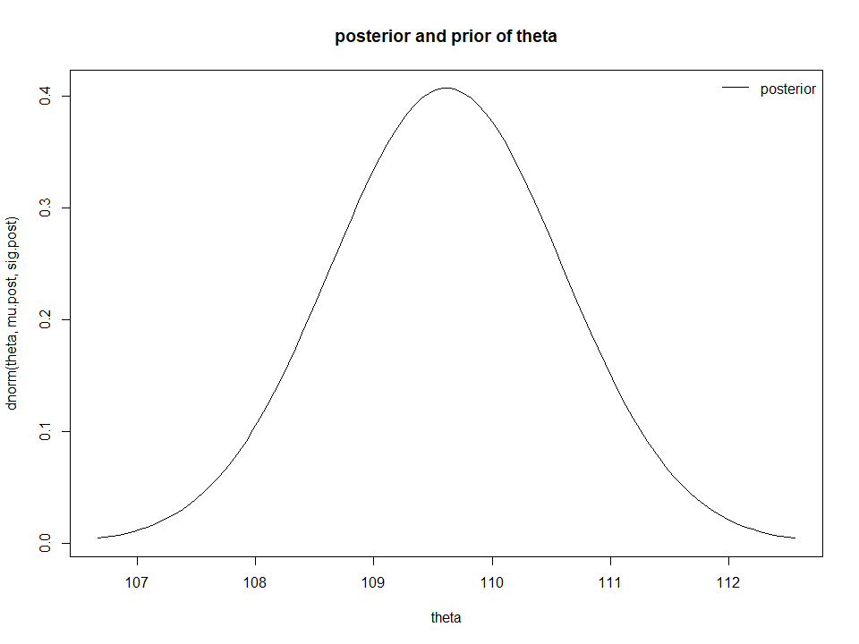

```r
# prior
mu0 = 100; sig0 = 5; n = 10; xbar = 110; sig = sqrt(10)

# posterior
c= 1/(sig^2/n) ; c0=1/sig0^2; w = c/(c+c0)
mu.post = w * xbar + (1-w)* mu0
sig.post = sqrt(1/(c+c0))

theta=seq(mu.post-3*sig.post, mu.post+3*sig.post, length=100)

plot(theta, dnorm(theta,mu.post, sig.post), type="l",main="posterior and prior of theta")
legend("topright",legend="posterior",lty=c(1),bty="n")
```

# $\theta의 사후 분포$

```r
mu.post
```

```
## [1] 109.6154
```

```r
sig.post #사후분포의 표준편차
```

```
## [1] 0.9805807
```

# 2번 문제

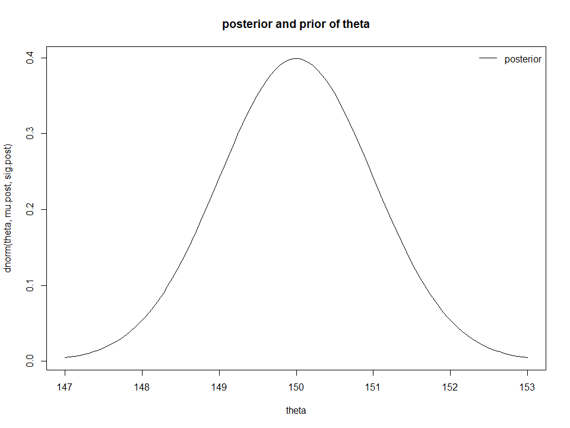

```r
mu0 = 150; sig0 = sqrt(21)
sig = sqrt(21)
n = 20
xbar = 150

# posterior
c= 1/(sig^2/n) ; c0=1/sig0^2; w = c/(c+c0)
mu.post = w * xbar + (1-w)* mu0
sig.post = sqrt(1/(c+c0))

theta=seq(mu.post-3*sig.post, mu.post+3*sig.post, length=100)
ftheta = dnorm(theta,mu.post,sig.post)

plot(theta, dnorm(theta,mu.post, sig.post), type="l",main="posterior and prior of theta")
legend("topright",legend="posterior",lty=c(1),bty="n")
```

2-(2)

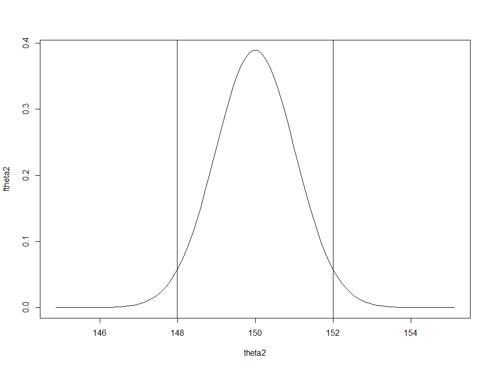

```r
#π(θ)=1일때는 다음과 같다.
mu.post2 = 150
sig.post2 = sqrt(21/20)

theta2 = seq(mu.post2-5*sig.post2, mu.post2+5*sig.post2, length=100)
ftheta2 = dnorm(theta2,mu.post2,sig.post2)
prob2 = ftheta2/sum(ftheta2)

# 사후 분포 mu.post2에 대한 95% 신뢰구간
lower_bound <- mu.post2 - 1.96*sig.post2
upper_bound <- mu.post2 + 1.96*sig.post2


plot(theta2, ftheta2, type = "l")
abline(v = c(lower_bound, upper_bound))
```

```r
c(lower_bound, upper_bound)
```

```
## [1] 147.9916 152.0084
```

2-(3)

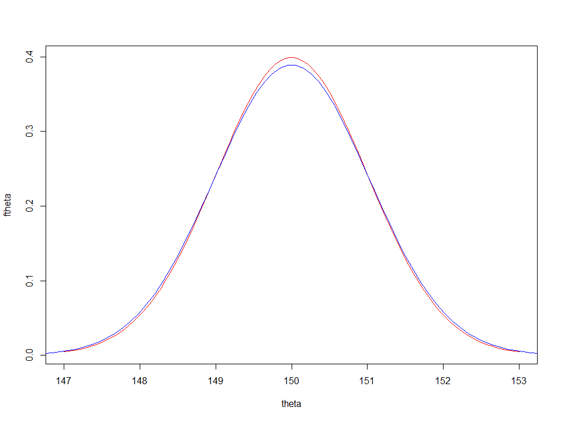

```r
plot(theta, ftheta, type='l', col='red')
lines(theta2, ftheta2, type='l', col='blue')
```

2-(4)

```r
# 사후분포 평균, 표준편차
mu.post
```

```
## [1] 150
```

```r
sig.post
```

```
## [1] 1
```

```r
# 예측분포
n_new = 10
s_new = sig / sqrt(n_new) # new관측치 평균에 대한 표준편차
mu.new = mu.post + 0
sig.new = sqrt( sig.post^2 + s_new^2 )
mu.new
```

```
## [1] 150
```

```r
sig.new
```

```
## [1] 1.760682
```

2-(5)

2-(4)에서 10개의 미래 관측치의 평균이 (150, 153)의 구간에 속할 확률은?

```r
prob = pnorm(153, mu.new, sig.new) - pnorm(150, mu.new, sig.new)
prob
```

```
## [1] 0.4557988
```

# 3번 문제

1. $\pi(\theta) = 1$, $\pi(\sigma^2) = \frac{1}{\sigma^2}$, $\pi(\theta, \sigma^2) = \pi(\theta) \cdot \pi(\sigma^2)$
2. $L(\theta, \sigma^2 | x_1, \ldots, x_n) = (2\pi\sigma^2)^{-n/2} \exp \left( -\frac{\sum_{i=1}^{n} (x_i - \theta)^2}{2\sigma^2} \right)$
3. $\pi(\theta, \sigma^2 | x_1, \ldots, x_n) \propto (2\pi\sigma^2)^{-n/2} \exp \left( -\frac{\sum_{i=1}^{n} (x_i - \theta)^2}{2\sigma^2} \right) \cdot \pi(\theta) \cdot \pi(\sigma^2)$

$\theta$의 사후분포: $\pi(\theta | x_1, \ldots, x_n, \sigma^2) \sim N(\bar{x}, \sigma^2/n)$

$\sigma^2$의 사후분포: $\pi(\sigma^2 | x_1, \ldots, x_n) \sim IG \left( \frac{n-1}{2}, \frac{S}{2} \right)$

# 4번 문제

P166의 공식에 따라서 $\theta$와 $\sigma^2$의 사후 분포를 유도하면

4-(1)

```r
x=c(95,77,63,34,87,89,92,85,98,52,48,72,89,63,67,78,92,85,78,99)
xbar =mean(x)
#
s = sd(x)

n = 20
xbar;s^2/20
```

```
## [1] 77.15
```

```
## [1] 15.91724
```

```r
#
```

$π(θ|x1,...,x20,\sigma^2)$ ~ $N(77.15, σ^2/20)$ 이다.

4-(2)

4-(3) P167, 분산을 모를 경우 정규 평균 $\theta$에 대한 고전적 추론의 결과와 일치함

4-(4)

```r
a = (20-1)/2
b = (n-1)*s^2/2
sig_hat = b/(a-1)
sig_hat
```

```
## [1] 355.7971
```

```r
var(x)
```

```
## [1] 318.3447
```

베이즈 추정치 분산이 더 크게 나타난다.

# 5번 문제

5-(1)

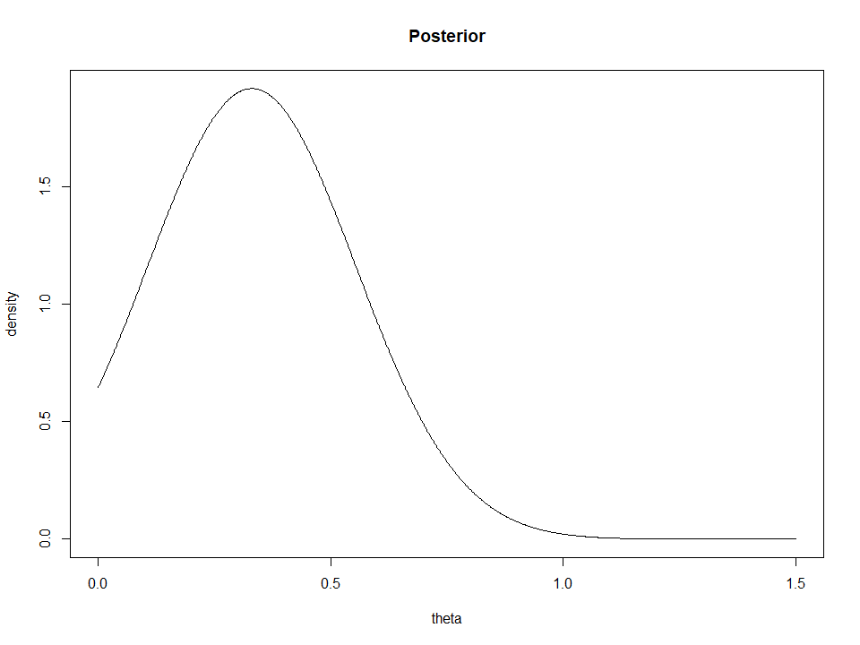

```r
n = 20; x_bar = 0.33

# 사후분포
theta = seq(0, 1.5, length.out = 1000)
posterior = dtnorm(theta, mean = x_bar, sd = sqrt(1/n), lower = 0)
plot(theta, posterior, type = "l", xlab = "theta", ylab = "density", main = "Posterior")
```

5-(2)

```r
prob = posterior/sum(posterior)
HPD <- HPDgrid(prob,0.95)
HPD.grid <- c(min(theta[HPD$index]), max(theta[HPD$index]))
HPD.grid
```

```
## [1] 0.0000000 0.7057057
```

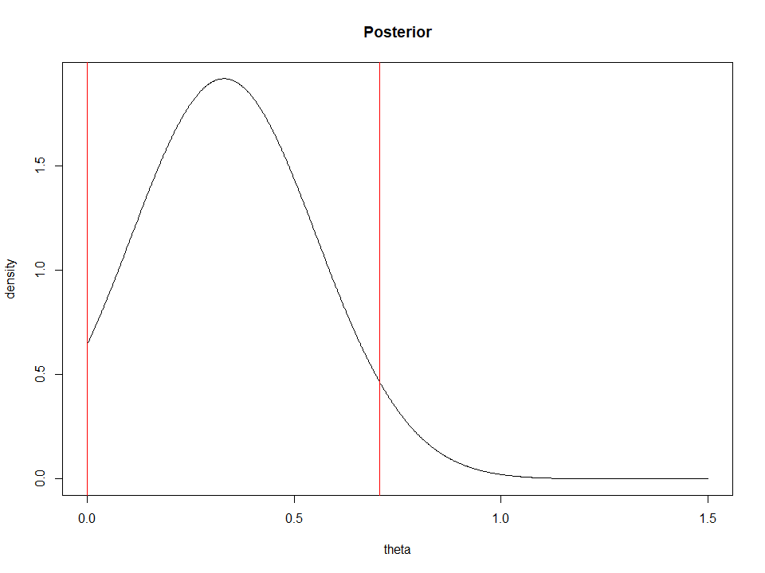

```r
plot(theta, posterior, type = "l", xlab = "theta", ylab = "density", main = "Posterior")
abline(v=HPD.grid, col ='red')
```